# CS524 Project: Flux Balance Analysis for Metabolic Networks

## 1. Introduction

Biological systems has numerous interconnected metabolic (chemical) reactions that convert nutrients into energy, biomass, and other products, forming a large **metabolic network**. Understanding how the reaction ﬂuxes are distributed across a metabolic network is an important question in biology. However, it is hard to obtain from experimental measurements, as there is no method that can monitor all reactions at the same time.

Flux Balance Analysis (FBA) is a computational method to model the reaction ﬂuxes in a metabolic network with a steady state assumption. It uses a complete set of all reactions in a cell/organism, and formulate a linear program model to optimize a biological objective such as growth rate, and hence obtaining a metabolic network model with optimal ﬂux distribution. FBA is an important tool and has been implemented in some bioinformatics softwares.

> Experimentally determining all the indentities of reactions in a cell is a relatively easy task: these reactions are catalyzed by certain enzymes (or just exchanging some substances with the exter al space), and scientists can read from the genome (all genes) of an organism and know what enzymes it has, corresponding to what reactions is has.

In this project, I will use the idea of FBA to construct metabolic models using public data, and then perform subsequent analyses. These contains finding critical pathways and flux variability analysis, which are also biological-relevant tasks. The methods of them will be detailed in section 3 with implementation in GAMSPy.

## 2. Data

### 2.1 The data pipeline

The data we use in this project comes from the BiGG Models http://bigg.ucsd.edu/. These are raw data come from experimental measurement of all metabolites (i.e. intermeidate substrates) and all reactions and their identities. They are stored in JSON format, and we will first transform to DataFrames, then to GAMSPy parameters.

The common objective of optimization for simple organisms are defined as "biomass accumulation". This is an idea similar to taking into some nutrient and grow, and it wants to maximize the growth rate. People have defined some biomass reaction which transform certain amounts of a set of metabolites into "biomass". However, for more complex living systems, like human, there is not a simple objective like this. Researchers are likely to define some objective of interest, like maximizing "something", based on what they are studying, so a biomass reaction is not contained. In this project, I only fetch and use the organisms that have a biomass objective.

```python
import requests
import json
import pandas as pd
import os
import time

import gamspy as gp
import numpy as np
import matplotlib.pyplot as plt
```

The simplest model in the database, E. coli (core), will be use for illustration for section 2&3.

```python
# select one model
NAME = "E. coli (core)"

names_dict = {"E. coli (core)":"e_coli_core",
              "H. pylori": 'iIT341',
#         "E. coli": "iAF1260",
         "Brewer's yeast (S. cerevisiae)": "iMM904",
         "House mouse (M. musculus)": "iMM1415"}

def fetch_data(model_name, save_loc=None):
    url = f"http://bigg.ucsd.edu/static/models/{model_name}.json"
    response = requests.get(url)
    if save_loc:
        with open(save_loc, "wb") as f:
            f.write(response.content)
    return response.json()

if os.path.exists(f"data/{names_dict[NAME]}.json"):
    with open(f"data/{names_dict[NAME]}.json", "r") as f:
        data_json = json.load(f)
        print("Loaded from local file.")
else:
    if not os.path.exists("data"):
        os.makedirs("data")
    data_json = fetch_data(names_dict[NAME], f"data/{names_dict[NAME]}.json")
    print("Fetched from web and saved locally.")

data_json.keys()
```

```
Loaded from local file.
```

```
dict_keys(['metabolites', 'reactions', 'genes', 'id', 'compartments', 'version'])
```

```python
metabolites_df = pd.DataFrame(data_json['metabolites'])
metabolites_df.head()
```

|  | id | name | compartment | charge | formula | notes | annotation |
| --- | --- | --- | --- | --- | --- | --- | --- |
| 0 | glc__D_e | D-Glucose | e | 0 | C6H12O6 | {'original_bigg_ids': ['glc_D_e']} | {'bigg.metabolite': ['glc__D'], 'biocyc': ['ME... |
| 1 | gln__L_c | L-Glutamine | c | 0 | C5H10N2O3 | {'original_bigg_ids': ['gln_L_c']} | {'bigg.metabolite': ['gln__L'], 'biocyc': ['ME... |
| 2 | gln__L_e | L-Glutamine | e | 0 | C5H10N2O3 | {'original_bigg_ids': ['gln_L_e']} | {'bigg.metabolite': ['gln__L'], 'biocyc': ['ME... |
| 3 | glu__L_c | L-Glutamate | c | -1 | C5H8NO4 | {'original_bigg_ids': ['glu_L_c']} | {'bigg.metabolite': ['glu__L'], 'biocyc': ['ME... |
| 4 | glu__L_e | L-Glutamate | e | -1 | C5H8NO4 | {'original_bigg_ids': ['glu_L_e']} | {'bigg.metabolite': ['glu__L'], 'biocyc': ['ME... |

```python
reactions_df = pd.DataFrame(data_json['reactions'])
lb_as_min = reactions_df['lower_bound'].min()
ub_as_max = reactions_df['upper_bound'].max()
reactions_df[['id', 'name', 'metabolites', 'lower_bound', 'upper_bound']][15:20]
```

|  | id | name | metabolites | lower_bound | upper_bound |
| --- | --- | --- | --- | --- | --- |
| 15 | ATPM | ATP maintenance requirement | {'adp_c': 1.0, 'atp_c': -1.0, 'h2o_c': -1.0, '... | 8.39 | 1000.0 |
| 16 | PPCK | Phosphoenolpyruvate carboxykinase | {'adp_c': 1.0, 'atp_c': -1.0, 'co2_c': 1.0, 'o... | 0.00 | 1000.0 |
| 17 | ACt2r | Acetate reversible transport via proton symport | {'ac_c': 1.0, 'ac_e': -1.0, 'h_c': 1.0, 'h_e':... | -1000.00 | 1000.0 |
| 18 | PPS | Phosphoenolpyruvate synthase | {'amp_c': 1.0, 'atp_c': -1.0, 'h2o_c': -1.0, '... | 0.00 | 1000.0 |
| 19 | ADK1 | Adenylate kinase | {'adp_c': 2.0, 'amp_c': -1.0, 'atp_c': -1.0} | -1000.00 | 1000.0 |

```python
reactions_df = pd.DataFrame(data_json['reactions'])

reaction_mat_df = pd.concat([reactions_df[['id', 'name']],
           pd.DataFrame(reactions_df['metabolites'].to_list()).fillna(0) ],
           axis=1)
# find biomass reaction
biomass_rxn_idx = reaction_mat_df['name'].str.contains('biomass', case=False)
# replace id to "biomass"
reaction_mat_df.at[biomass_rxn_idx.idxmax(), 'id'] = 'biomass'
reactions_df.at[biomass_rxn_idx.idxmax(), 'id'] = 'biomass'
# get columes other than id name
display(reaction_mat_df[reaction_mat_df.columns.difference(['id', 'name'])].head())

# Convert wide format to long format
reaction_mat_long = pd.melt(
    reaction_mat_df,
    id_vars=['id'],
    value_vars=[col for col in reaction_mat_df.columns if col not in ['id', 'name']],
    var_name='metabolite',
    value_name='coefficient'
)

# Display the result
print(f"Shape: {reaction_mat_long.shape}")
reaction_mat_long.columns = ['rxn', 'metabolite', 'coefficient']
reaction_mat_long.head(5)
reactions_df.rename(columns={'id':'rxn'}, inplace=True)
```

|  | 13dpg_c | 2pg_c | 3pg_c | 6pgc_c | 6pgl_c | ac_c | ac_e | acald_c | acald_e | accoa_c | ... | pyr_e | q8_c | q8h2_c | r5p_c | ru5p__D_c | s7p_c | succ_c | succ_e | succoa_c | xu5p__D_c |
| --- | --- | --- | --- | --- | --- | --- | --- | --- | --- | --- | --- | --- | --- | --- | --- | --- | --- | --- | --- | --- | --- |
| 0 | 0.0 | 0.0 | 0.0 | 0.0 | 0.0 | 0.0 | 0.0 | 0.0 | 0.0 | 0.0 | ... | 0.0 | 0.0 | 0.0 | 0.0 | 0.0 | 0.0 | 0.0 | 0.0 | 0.0 | 0.0 |
| 1 | 0.0 | 0.0 | 0.0 | 0.0 | 0.0 | 0.0 | 0.0 | 0.0 | 0.0 | 1.0 | ... | 0.0 | 0.0 | 0.0 | 0.0 | 0.0 | 0.0 | 0.0 | 0.0 | 0.0 | 0.0 |
| 2 | 0.0 | 0.0 | 0.0 | 0.0 | 0.0 | 0.0 | 0.0 | 0.0 | 0.0 | 0.0 | ... | 0.0 | 0.0 | 0.0 | 0.0 | 0.0 | 0.0 | 0.0 | 0.0 | 0.0 | 0.0 |
| 3 | 1.0 | 0.0 | -1.0 | 0.0 | 0.0 | 0.0 | 0.0 | 0.0 | 0.0 | 0.0 | ... | 0.0 | 0.0 | 0.0 | 0.0 | 0.0 | 0.0 | 0.0 | 0.0 | 0.0 | 0.0 |
| 4 | 0.0 | 0.0 | 0.0 | 1.0 | -1.0 | 0.0 | 0.0 | 0.0 | 0.0 | 0.0 | ... | 0.0 | 0.0 | 0.0 | 0.0 | 0.0 | 0.0 | 0.0 | 0.0 | 0.0 | 0.0 |

5 rows × 72 columns

```
Shape: (6840, 3)
```

```python
reactions_df[['rxn', 'name', 'metabolites', 'lower_bound', 'upper_bound']][15:20]
```

|  | rxn | name | metabolites | lower_bound | upper_bound |
| --- | --- | --- | --- | --- | --- |
| 15 | ATPM | ATP maintenance requirement | {'adp_c': 1.0, 'atp_c': -1.0, 'h2o_c': -1.0, '... | 8.39 | 1000.0 |
| 16 | PPCK | Phosphoenolpyruvate carboxykinase | {'adp_c': 1.0, 'atp_c': -1.0, 'co2_c': 1.0, 'o... | 0.00 | 1000.0 |
| 17 | ACt2r | Acetate reversible transport via proton symport | {'ac_c': 1.0, 'ac_e': -1.0, 'h_c': 1.0, 'h_e':... | -1000.00 | 1000.0 |
| 18 | PPS | Phosphoenolpyruvate synthase | {'amp_c': 1.0, 'atp_c': -1.0, 'h2o_c': -1.0, '... | 0.00 | 1000.0 |
| 19 | ADK1 | Adenylate kinase | {'adp_c': 2.0, 'amp_c': -1.0, 'atp_c': -1.0} | -1000.00 | 1000.0 |

## 3. Approaches

### 3.1 FBA

In this problem setting, we have metabolites $\{m_j\} \ (i=1,2,...M)$, reactions $\{r_i\} \ (j=1,2,...R)$ (access from public data). Each reaction is consuming and producing some metabolites, with some given chemical ratio, which is called the stoichiometric coefficients. We define the **stoichiometric coefficients** $s_{ij}$ is the amount of $m_j$ produced by **one unit of forward reaction** $r_i$. For example,

$$\text{ATP}^{4+} + \text{H}_2\text{O} \to \text{ADP}^{3-} + \text{HPO}_4^{2-} + \text{H}^+$$

this reaction will have $s_{i_1, \text{ATP}^{4+}} = s_{i_2, \text{H}_2\text{O}} = -1$, and $s_{i_3, \text{ADP}^{3-}}=...=+1$

We also have some artificial "reactions": (1) exchanges: the reaction that only produce (or its reverse way consumes) a metabolite, which corresponds to processes like getting $\mathrm O_2$ from the outside of the cell (this will only have $s_{i', O_2} = +1$). (2) a special "biomass production" reaction, which is used to define the objective.

The decision variables are the "flux" of each reaction $r_i$, which corresponds to the reaction rate (the amount of the reaction happens at unit time), denoted $v_i$. The objective is the flux of biomass reaction, $v_\text{biomass}$, also known as **growth rate**.

The constraints applied in FBA is from that idea that the cell should be in a steady state - any metabolites should keep a stable concentration, instead of building up or running out (note: "biomass" that can build up is not include in metabolites, and all substances that have an input source, e.g. oxygen, is not included in metabolites either). A cell is like a factory, producing at a constant rate. This **mass balance condition** is written as:

$$ \frac{d}{dt}[m_j] = \sum_i s_{ij} v_i = 0, \qquad \forall j =1,2,...,M$$

For each metabolite, the reactions producing it and consuming it have a net rate of 0.

In addition, fluxes have constraints from thermodynamics, having both upperbound and lowerbound. $v_i$ can be negative, because the reactions in biological systems are usually reversible.

$$ lb_i < v_i < ub_i $$

So the optimization problem is formulated as a standard LP, where all dependencies are linear. This can be directly modeled in GAMSPy and solved with common LP solvers.

```python
gc = gp.Container()

# define sets
metabolite = gp.Set(gc, 'metabolite', description="metabolites", records=metabolites_df['id'])
rxn = gp.Set(gc, 'rxn', description="reactions", records=reactions_df['rxn'])

# stoichiometric coefficients used for flux balance constraints
stoichiometry = gp.Parameter(gc, 'stoichiometry', description="stoichiometric coefficients",
                     domain=[rxn, metabolite], records=reaction_mat_long)

reaction_ub = gp.Parameter(gc, 'reaction_ub', description="reaction upper bounds",
                          domain=[rxn],
                          records=reactions_df[['rxn', 'upper_bound']])
reaction_lb = gp.Parameter(gc, 'reaction_lb', description="reaction lower bounds",
                          domain=[rxn],
                          records=reactions_df[['rxn', 'lower_bound']])
```

```python
# variables
vflux = gp.Variable(gc, 'flux', domain=rxn, description="reaction fluxes")

# bounds - CRITICAL: These must be set for FBA to work!
vflux[rxn].lo = reaction_lb[rxn]
vflux[rxn].up = reaction_ub[rxn]

# constraints
mass_balance = gp.Equation(gc, 'flux_balance',
                            domain=metabolite,)
mass_balance[metabolite] = gp.Sum(rxn, stoichiometry[rxn, metabolite] * vflux[rxn]) == 0

growth_rate = gp.Variable(gc, 'growth_rate', description="growth rate")
def_growth_rate = gp.Equation(gc, 'define_growth_rate')
def_growth_rate[:] = vflux['biomass'] == growth_rate

fba = gp.Model(gc, 'FBA_model', description="Flux Balance Analysis model",
               objective = growth_rate,
               equations = [mass_balance, def_growth_rate],
               sense = gp.Sense.MAX,
               problem=gp.Problem.LP,
               )

fba.solve(options=gp.Options(equation_listing_limit=0))
```

|  | Solver Status | Model Status | Objective | Num of Equations | Num of Variables | Model Type | Solver | Solver Time |
| --- | --- | --- | --- | --- | --- | --- | --- | --- |
| 0 | Normal | OptimalGlobal | 0.873922 | 73 | 96 | LP | CPLEX | 0.001 |

The solver find the optimal global with objective 0.8739. This is the growth rate estimation for this E. Coli model. Not all reactions have non-zero fluxes, because all the reaction set is the set of all possible reactions in the cell, which may not contribute to biomass production.

```python
display(vflux.records)
```

|  | rxn | level | marginal | lower | upper | scale |
| --- | --- | --- | --- | --- | --- | --- |
| 0 | PFK | 7.477382 | 0.000000 | 0.0 | 1000.0 | 1.0 |
| 1 | PFL | 0.000000 | -0.007639 | 0.0 | 1000.0 | 1.0 |
| 2 | PGI | 4.860861 | 0.000000 | -1000.0 | 1000.0 | 1.0 |
| 3 | PGK | -16.023526 | 0.000000 | -1000.0 | 1000.0 | 1.0 |
| 4 | PGL | 4.959985 | 0.000000 | 0.0 | 1000.0 | 1.0 |
| ... | ... | ... | ... | ... | ... | ... |
| 90 | NADH16 | 38.534610 | 0.000000 | 0.0 | 1000.0 | 1.0 |
| 91 | NADTRHD | 0.000000 | -0.001273 | 0.0 | 1000.0 | 1.0 |
| 92 | NH4t | 4.765319 | 0.000000 | -1000.0 | 1000.0 | 1.0 |
| 93 | O2t | 21.799493 | 0.000000 | -1000.0 | 1000.0 | 1.0 |
| 94 | PDH | 9.282533 | 0.000000 | 0.0 | 1000.0 | 1.0 |

95 rows × 6 columns

Visualization of FBA results.

```python
# Sort by level
flux_data = vflux.l.records.sort_values('level', ascending=True)
```

```python
def visualize_fluxes_records(flux_data, model_name, logscale=False, lb_as_min=0, ub_as_max=1, appendix=""):
    flux_data = flux_data.sort_values('level', ascending=True)
    colors = ['red' if rxn == 'biomass' else 'C0' for rxn in flux_data['rxn']]

    fig, ax = plt.subplots(figsize=(8, 8))
    ax.barh(flux_data['rxn'], flux_data['level'], color=colors)
    ax.set_xlabel('Flux Level')
    if 'biomass' in flux_data['rxn'].values:
        _growth_rate = flux_data[flux_data['rxn'] == 'biomass']['level'].values[0]
        ax.text(_growth_rate,
                'biomass',
                '  ← growth rate = {:.4f}'.format(_growth_rate),
                va='center',
                fontsize=10)
    # find the maximum absolute flux for setting x-limits, but excluding max
    middle_flux_data = flux_data[(flux_data['level'] > lb_as_min * 0.99) & (flux_data['level'] < ub_as_max * 0.99)]
    x_max = middle_flux_data['level'].max()
    x_min = middle_flux_data['level'].min()
    if logscale:
        ax.set_xscale('symlog')
    ax.set_xlim(x_min, x_max)
    ax.set_ylabel('Reaction')
    ax.set_title(f'Reaction Fluxes of {model_name} Model {appendix}')
    ax.grid(True, linestyle=':', alpha=0.5)
    plt.tight_layout()
    plt.show()
    return fig, ax

#visualize_fluxes_records(flux_data, NAME)
```

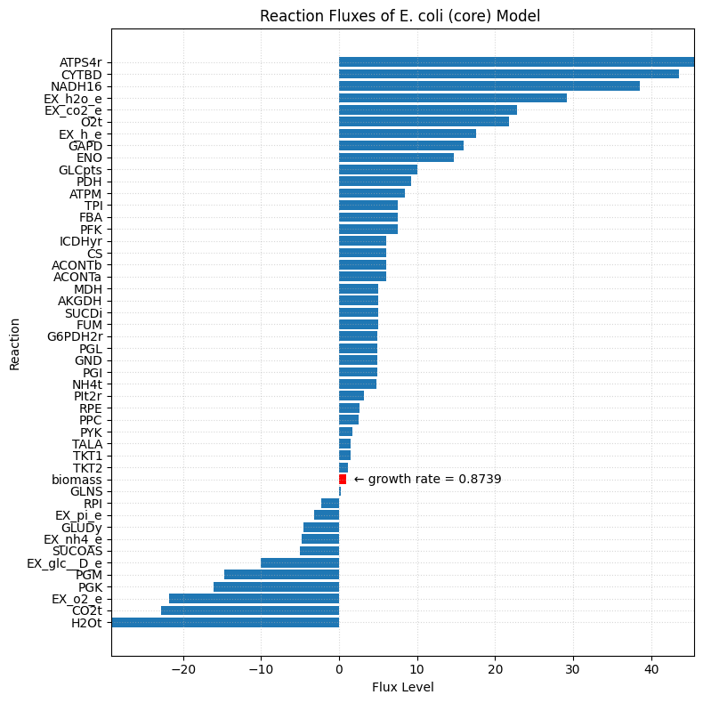

```
(<Figure size 800x800 with 1 Axes>,
 <Axes: title={'center': 'Reaction Fluxes of E. coli (core) Model '}, xlabel='Flux Level', ylabel='Reaction'>)
```

```python
visualize_fluxes_records(flux_data, NAME)
```

### 3. 2 Critical reaction pathways

A reaction is *critical* if its absence lead to significant negative effect on growth rate, or even stops the growth, while other reactions may be compensated by different reactions. This is a biological relevant task because an organism may have a mutation and lose an enzyme to perform a certain reaction; people want to know or predict the effects of these mutations, or make use of them. Based on this, we can also make an "essential" model of an organism consists of all the critical reactions.

The method of finding critical reactions is simply fixing the flux of one reaction to zero, then solve the same LP, and examine the difference from the previous optimal objective.

In my implementation, I found that the deletion of some reaction will make the problem *infeasible*. This may relate to some reactions that are important to keep the mass balance condition, absence of them breaks the network and makes it impossible to keep the balance. I detect them and also list these as critical reactions.

```python
growth_rate_with_mutation = []

for idx, rxn_i in enumerate(reactions_df['rxn']):
    print("processing rxn #", idx, end='\r')
    # additional equation constraint
    absence_of_rxn = gp.Equation(gc, f'absence_of_{rxn_i}')
    absence_of_rxn[:] = vflux[rxn_i] == 0
    fba_critical = gp.Model(gc, 'FBA_critical_model', description="Flux Balance Analysis model with reaction absence",
                   objective = growth_rate,
                   equations = [mass_balance, def_growth_rate, absence_of_rxn],
                   sense = gp.Sense.MAX,
                   problem=gp.Problem.LP,
                   )
    fba_critical.solve(options=gp.Options(equation_listing_limit=0))
    status = ""
    if "Infeasible" in fba_critical.status.name:
        new_growth_rate = 0.0
        status = fba_critical.status.name
    else:
        new_growth_rate = fba_critical.objective_value
        status = fba_critical.status.name
    change = new_growth_rate - fba.objective_value
    growth_rate_with_mutation.append(
        {'rxn': rxn_i, 'growth_rate': new_growth_rate, "change": change, 'status': status})

growth_rate_with_mutation = pd.DataFrame(growth_rate_with_mutation)
growth_rate_with_mutation
```

```
processing rxn # 94
```

|  | rxn | growth_rate | change | status |
| --- | --- | --- | --- | --- |
| 0 | PFK | 0.704037 | -0.169885 | OptimalGlobal |
| 1 | PFL | 0.873922 | 0.000000 | OptimalGlobal |
| 2 | PGI | 0.863160 | -0.010762 | OptimalGlobal |
| 3 | PGK | 0.000000 | -0.873922 | OptimalGlobal |
| 4 | PGL | 0.863813 | -0.010108 | OptimalGlobal |
| ... | ... | ... | ... | ... |
| 90 | NADH16 | 0.211663 | -0.662259 | OptimalGlobal |
| 91 | NADTRHD | 0.873922 | 0.000000 | OptimalGlobal |
| 92 | NH4t | 0.000000 | -0.873922 | OptimalGlobal |
| 93 | O2t | 0.211663 | -0.662259 | OptimalGlobal |
| 94 | PDH | 0.796696 | -0.077226 | OptimalGlobal |

95 rows × 4 columns

```python
flux_change_data = growth_rate_with_mutation.copy()
# drop very small values (maybe numerical errors)
flux_change_data = flux_change_data[np.abs(flux_change_data['change']) > 0.001 * fba.objective_value]
```

```python
print(f"Number of critical reactions: {flux_change_data.shape[0]}")
print(f"Number of non-zero fluxes in original FBA: {flux_data.shape[0]}")
```

```
Number of critical reactions: 48
Number of non-zero fluxes in original FBA: 48
```

The "core" model we use here is already an essential set of reactions in E. Coli (a minimum metabolic network for E. Coli), so it is expected that all of these reactions are critical reactions. The results make senes. We will do something more in the next part to show the number of critical reactions in a larger model with possible redundant.

Visualization of flux changes due to reaction deletions:

```python
def visualize_flux_change_records(flux_change_data, model_name, logscale=False, appendix=""):
    flux_change_data['is_infeasible'] = flux_change_data['status'].str.contains('Infeasible')

    # Sort: feasible by change (ascending), then infeasible at bottom
    feasible = flux_change_data[~flux_change_data['is_infeasible']].sort_values('change', ascending=True)
    infeasible = flux_change_data[flux_change_data['is_infeasible']].sort_values('change', ascending=True)
    flux_change_data = pd.concat([infeasible, feasible])

    colors = ['red' if is_inf else 'C1' for is_inf in flux_change_data['is_infeasible']]

    fig, ax = plt.subplots(figsize=(8, 8))

    # put reference bars
    ax.barh(flux_change_data['rxn'], fba.objective_value, color='C1', label='growth rate change')

    # plot feasible and infeasible separately for legend
    feasible_data = flux_change_data[~flux_change_data['is_infeasible']]
    infeasible_data = flux_change_data[flux_change_data['is_infeasible']]

    old_optimal = fba.objective_value
    ax.barh(feasible_data['rxn'], feasible_data['change'] + old_optimal, color='lightgrey')
    ax.barh(infeasible_data['rxn'], old_optimal, color='red', label='Infeasible')

    ax.set_xlabel('Change in Growth Rate')
    ax.set_ylabel('Reaction')
    ax.set_title(f'Critical Reaction Fluxes Effects on Growth Rate \n of {model_name} Model {appendix}')
    ax.legend(loc='upper left')
    ax.grid(True, linestyle=':', alpha=0.5)
    if logscale:
        ax.set_xscale('symlog')
    plt.tight_layout()
    plt.show()
```

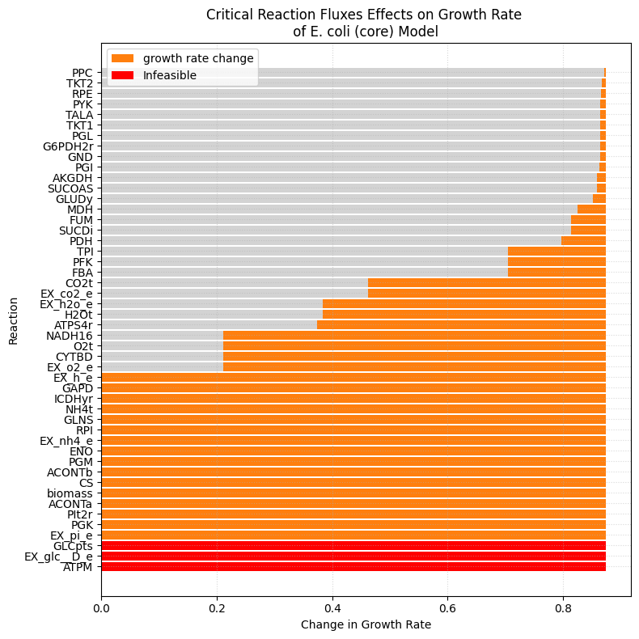

```python
visualize_flux_change_records(flux_change_data, NAME)
```

We can see there are different levels of decrease in the growth rate caused by deleting different reactions. There are a set of reactions whose absence will cause the growth to stop.

### 3.3 Flux variability analysis

Flux variability analysis (FVA) is that fixing the objective value obtained from FBA (or only allowing a small amount of change) to see what are the available range of each reaction flux. This task is important for researchers to analyze which reactions are sensitive. In real world, people will perform this FVA technique on the reactions they are interested in.

For each reaction of interest $r_i$, we solve 2 LPs. We fix the objective value solved from FBA (I define the constraint is $\geq$ 0.99 * objective), and (1) minimize, (2) maximize the flux $v_i$. This will give the lower bound and upper bound of flux $v_i$.

```python
fva_results = []

for idx, rxn_i in enumerate(reactions_df['rxn']):
    print("processing rxn #", idx, end='\r')
    # fix objective value to optimal
    fixed_objective = fba.objective_value
    fix_growth = gp.Equation(gc, 'fix_growth_rate')
    fix_growth[:] = growth_rate >= 0.99 * fba.objective_value

    # objectives for min and max
    flux_obj = gp.Variable(gc, 'min_flux_obj', description="min flux objective")
    def_flux_obj = gp.Equation(gc, 'define_min_flux_obj')
    def_flux_obj[:] = flux_obj == vflux[rxn_i]

    # minimize flux
    fva_min_model = gp.Model(gc, f'FVA_min_model_{rxn_i}', description="FVA lower bound model",
                   objective = flux_obj,
                   equations = [mass_balance, def_growth_rate, fix_growth, def_flux_obj],
                   sense = gp.Sense.MIN,
                   problem=gp.Problem.LP,
                   )
    fva_min_model.solve(options=gp.Options(equation_listing_limit=0))

    fva_lb_i = fva_min_model.objective_value

    # maximize flux
    fva_max_model = gp.Model(gc, f'FVA_max_model_{rxn_i}', description="FVA upper bound model",
                   objective = flux_obj,
                   equations = [mass_balance, def_growth_rate, fix_growth, def_flux_obj],
                   sense = gp.Sense.MAX,
                   problem=gp.Problem.LP,
                   )
    fva_max_model.solve(options=gp.Options(equation_listing_limit=0))
    fva_ub_i = fva_max_model.objective_value

    # get results
    fva_results.append({
        'rxn': rxn_i,
        'fva_lb': fva_lb_i,
        'fva_ub': fva_ub_i,
        'range': fva_ub_i - fva_lb_i
    })
fva_results = pd.DataFrame(fva_results)
```

```
processing rxn # 94
```

```python
def visualize_fva_results(fva_results, flux_results, growth_rate_value, model_name, logscale=False, lb_as_min=lb_as_min, ub_as_max=ub_as_max,
                          appendix=""):
    """
    This function is written by Claude Sonnet 4.5
    Visualize Flux Variability Analysis results with min-max ranges and FBA optimal fluxes.

    Parameters:
    -----------
    fva_results : pd.DataFrame
        DataFrame with columns: 'rxn', 'fva_lb', 'fva_ub', 'range'
    flux_data : pd.DataFrame or gamspy records
        FBA flux data with columns: 'rxn', 'level'
    growth_rate_value : float
        The optimal growth rate from FBA
    model_name : str
        Name of the model for the plot title
    """
    # Handle both DataFrame and GAMS records
    if hasattr(flux_results, 'records'):
        flux_df = flux_results.records[['rxn', 'level']].rename(columns={'level': 'fba_flux'})
    else:
        flux_df = flux_results[['rxn', 'level']].rename(columns={'level': 'fba_flux'})

    # Merge FVA results with original FBA flux data
    fva_with_fba = fva_results.merge(flux_df, on='rxn', how='left')

    # Filter reactions with non-zero FBA flux for better visualization
    fva_plot_data = fva_with_fba[fva_with_fba['fba_flux'].abs() > 1e-6].copy()

    # Sort by FBA flux value
    fva_plot_data = fva_plot_data.sort_values('fba_flux', ascending=True)

    # Create the visualization
    fig, ax = plt.subplots(figsize=(8, 8))

    # Create stacked bars: from min to FBA flux, then from FBA flux to max
    width1 = fva_plot_data['fba_flux'] - fva_plot_data['fva_lb']
    width2 = fva_plot_data['fva_ub'] - fva_plot_data['fba_flux']

    # Plot the range as two stacked segments
    ax.barh(fva_plot_data['rxn'], width1, left=fva_plot_data['fva_lb'],
            color='lightblue', alpha=0.6, label='FVA range (min to FBA)')
    ax.barh(fva_plot_data['rxn'], width2, left=fva_plot_data['fba_flux'],
            color='lightcoral', alpha=0.6, label='FVA range (FBA to max)')

    # Highlight the FBA optimal flux value with thick vertical markers
    ax.scatter(fva_plot_data['fba_flux'], fva_plot_data['rxn'],
               color='darkblue', s=80, marker='|', linewidths=3,
               zorder=5, label='FBA optimal flux')

    # Highlight biomass reaction
    if 'biomass' in fva_plot_data['rxn'].values:
        biomass_flux = fva_plot_data[fva_plot_data['rxn'] == 'biomass']['fba_flux'].values[0]
        ax.text(biomass_flux, 'biomass',
                f'  ← growth rate = {growth_rate_value:.4f}',
                va='center', fontsize=10)

    # Set x-axis limits, filtering out extreme outliers (abs > 500)
    reasonable_data = fva_plot_data[(fva_plot_data['fva_lb'] > lb_as_min/2) & (fva_plot_data['fva_ub'] < ub_as_max/2)]
    if len(reasonable_data) > 0:
        x_max = reasonable_data['fva_ub'].max() + 1
        x_min = reasonable_data['fva_lb'].min() - 1
    else:
        x_max = fva_plot_data['fva_ub'].max() + 1
        x_min = fva_plot_data['fva_lb'].min() - 1

    # let flux_results in range
    ax.set_xlim(x_min, x_max)

    ax.set_xlabel('Flux Level')
    ax.set_ylabel('Reaction')
    ax.set_title(f'Flux Variability Analysis (>99% of optimal growth rate) \n of {model_name} Model {appendix}')
    ax.legend(loc='best')
    ax.grid(True, linestyle=':', alpha=0.5)
    if logscale:
        ax.set_xscale('symlog')
    plt.tight_layout()
    plt.show()

    print(f"\nShowing {len(fva_plot_data)} reactions with non-zero FBA flux")
    print(f"X-axis range: [{x_min:.2f}, {x_max:.2f}]")
    return fig, ax
```

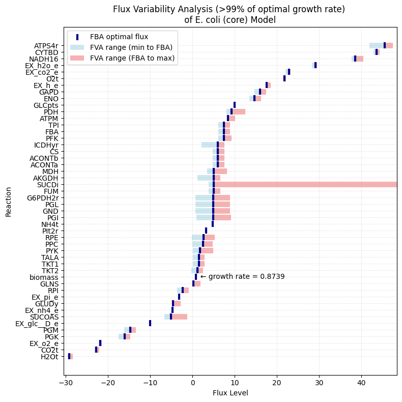

```
Showing 48 reactions with non-zero FBA flux
X-axis range: [-30.48, 48.41]
```

```
(<Figure size 800x800 with 1 Axes>,
 <Axes: title={'center': 'Flux Variability Analysis (>99% of optimal growth rate) \n of E. coli (core) Model '}, xlabel='Flux Level', ylabel='Reaction'>)
```

```python
# Use the function
visualize_fva_results(fva_results, flux_data, fba.objective_value, NAME)
```

The results of FVA can give biologists a sense of how much flexibility is allowed for certain reaction flux. And we see in this model the fluxes that have large magnitudes tend to have smaller ranges, meaning that the cell is highly rely on these reactions to have a high growth rate. These contains the reactions related to respiration (O2, CO2), water transport (H2O), and energy production (ATP, NADH), which is very consistent with the biologists' view.

What happen if we fix the growth rate to be exactly the optimal?

```
processing rxn # 94
```

[figure not shown]

```
Showing 48 reactions with non-zero FBA flux
X-axis range: [-30.18, 46.51]
```

```
(<Figure size 800x800 with 1 Axes>,
 <Axes: title={'center': 'Flux Variability Analysis (>99% of optimal growth rate) \n of E. coli (core) Model '}, xlabel='Flux Level', ylabel='Reaction'>)
```

```python
fva_results = []

for idx, rxn_i in enumerate(reactions_df['rxn']):
    print("processing rxn #", idx, end='\r')
    # fix objective value to optimal
    fixed_objective = fba.objective_value
    fix_growth = gp.Equation(gc, 'fix_growth_rate')
    fix_growth[:] = growth_rate == fba.objective_value

    # objectives for min and max
    flux_obj = gp.Variable(gc, 'min_flux_obj', description="min flux objective")
    def_flux_obj = gp.Equation(gc, 'define_min_flux_obj')
    def_flux_obj[:] = flux_obj == vflux[rxn_i]

    # minimize flux
    fva_min_model = gp.Model(gc, f'FVA_min_model_{rxn_i}', description="FVA lower bound model",
                   objective = flux_obj,
                   equations = [mass_balance, def_growth_rate, fix_growth, def_flux_obj],
                   sense = gp.Sense.MIN,
                   problem=gp.Problem.LP,
                   )
    fva_min_model.solve(options=gp.Options(equation_listing_limit=0))

    fva_lb_i = fva_min_model.objective_value

    # maximize flux
    fva_max_model = gp.Model(gc, f'FVA_max_model_{rxn_i}', description="FVA upper bound model",
                   objective = flux_obj,
                   equations = [mass_balance, def_growth_rate, fix_growth, def_flux_obj],
                   sense = gp.Sense.MAX,
                   problem=gp.Problem.LP,
                   )
    fva_max_model.solve(options=gp.Options(equation_listing_limit=0))
    fva_ub_i = fva_max_model.objective_value

    # get results
    fva_results.append({
        'rxn': rxn_i,
        'fva_lb': fva_lb_i,
        'fva_ub': fva_ub_i,
        'range': fva_ub_i - fva_lb_i
    })
fva_results = pd.DataFrame(fva_results)

visualize_fva_results(fva_results, flux_data, fba.objective_value, NAME)
```

## 4. General pipeline and results.

Several considerations:

- Some data file contains special characters in the IDs of metabolites or reactions. So I simplified them to numerical IDs.
- In larger systems, there are a lot of fluxes that hit the bounds. These are simple processes that have "abundant supply" and their values are not meaningful (these bounds are set so that the problem is bounded). So, in my post analysis (visualization and FVA), I excluded all reactions that hit the bounds.
- Analyzing critical pathways for large systems can be really time consuming. I make it an option that user can turn on. I display the cirtical and "essential" (causing zero growth rates) reactions as a result.

```python
def fetch_data(model_name, save_loc=None):
    url = f"http://bigg.ucsd.edu/static/models/{model_name}.json"
    response = requests.get(url)
    if save_loc:
        with open(save_loc, "wb") as f:
            f.write(response.content)
    return response.json()

def get_data_json(model_name, names_dict=names_dict):
    if os.path.exists(f"data/{names_dict[model_name]}.json"):
        with open(f"data/{names_dict[model_name]}.json", "r") as f:
            data_json = json.load(f)
            print("Loaded from local file.")
    else:
        if not os.path.exists("data"):
            os.makedirs("data")
        data_json = fetch_data(names_dict[model_name], f"data/{names_dict[model_name]}.json")
        print("Fetched from web and saved locally.")
    return data_json


def data_pipeline(model_name, names_dict=names_dict, use_numeric_ids=True):
    """Fetch and process model data into DataFrames.

    Parameters:
    -----------
    model_name : str
        Name of the model to fetch
    names_dict : dict
        Dictionary mapping model names to internal names
    use_numeric_ids : bool
        If True, use simplified numeric IDs (m1, m2, r1, r2, biomass)
        If False, use original BiGG IDs

    Returns:
    --------
    metabolites_df : pd.DataFrame
        Metabolites with columns: 'id', 'original_id', 'name'
    reactions_df : pd.DataFrame
        Reactions with columns: 'rxn', 'original_id', 'name', 'lower_bound', 'upper_bound'
    reaction_mat_long : pd.DataFrame
        Stoichiometric matrix in long format with columns: 'rxn', 'metabolite', 'coefficient'
    lb_as_min : float
        Minimum lower bound across all reactions
    ub_as_max : float
        Maximum upper bound across all reactions
    id_mappings : dict
        Mappings between numeric and original IDs (only when use_numeric_ids=True)
    """
    data_json = get_data_json(model_name, names_dict=names_dict)
    print(data_json.keys())

    metabolites_df = pd.DataFrame(data_json['metabolites'])
    reactions_df = pd.DataFrame(data_json['reactions'])
    lb_as_min = reactions_df['lower_bound'].min()
    ub_as_max = reactions_df['upper_bound'].max()

    # find biomass reaction
    biomass_rxn_idx = reactions_df['name'].str.contains('biomass', case=False)
    biomass_original_id = reactions_df.loc[biomass_rxn_idx.idxmax(), 'id']

    if use_numeric_ids:
        # Create numeric IDs for metabolites
        metabolites_df['num_id'] = ['m' + str(i+1) for i in range(len(metabolites_df))]
        metabolite_id_map = dict(zip(metabolites_df['id'], metabolites_df['num_id']))
        print(f"- Created {len(metabolite_id_map)} metabolite numeric IDs (m1 to m{len(metabolite_id_map)})")

        # Create numeric IDs for reactions
        reactions_df['num_id'] = ['r' + str(i+1) for i in range(len(reactions_df))]
        reactions_df.at[biomass_rxn_idx.idxmax(), 'num_id'] = 'biomass'
        reaction_id_map = dict(zip(reactions_df['id'], reactions_df['num_id']))
        print(f"- Created {len(reactions_df)} reaction numeric IDs (r1 to r{len(reactions_df)})")
        print(f"- Biomass reaction: {biomass_original_id} -> biomass")

        # Build reaction matrix with numeric IDs
        reaction_mat_df = pd.concat([reactions_df[['id', 'num_id', 'name']],
                pd.DataFrame(reactions_df['metabolites'].to_list()).fillna(0) ],
                axis=1)

        # Replace metabolite column names with numeric IDs
        metabolite_cols = [col for col in reaction_mat_df.columns if col not in ['id', 'num_id', 'name']]
        rename_map = {col: metabolite_id_map.get(col, col) for col in metabolite_cols}
        reaction_mat_df.rename(columns=rename_map, inplace=True)

        # Convert wide format to long format using numeric IDs
        numeric_metabolite_cols = [rename_map[col] for col in metabolite_cols]
        reaction_mat_long = pd.melt(
            reaction_mat_df,
            id_vars=['num_id'],
            value_vars=numeric_metabolite_cols,
            var_name='metabolite',
            value_name='coefficient'
        )
        reaction_mat_long.columns = ['rxn', 'metabolite', 'coefficient']

        # Update DataFrames to use numeric IDs as primary identifier
        reactions_df['original_id'] = reactions_df['id']
        reactions_df['rxn'] = reactions_df['num_id']
        reactions_df = reactions_df[['rxn', 'original_id', 'name', 'lower_bound', 'upper_bound']]

        metabolites_df['original_id'] = metabolites_df['id']
        metabolites_df['id'] = metabolites_df['num_id']
        metabolites_df = metabolites_df[['id', 'original_id', 'name']]

        # Create mapping dictionaries for visualization
        rxn_to_name = dict(zip(reactions_df['rxn'], reactions_df['name']))
        rxn_to_original = dict(zip(reactions_df['rxn'], reactions_df['original_id']))
        metabolite_to_name = dict(zip(metabolites_df['id'], metabolites_df['name']))
        metabolite_to_original = dict(zip(metabolites_df['id'], metabolites_df['original_id']))

        id_mappings = {
            'rxn_to_name': rxn_to_name,
            'rxn_to_original': rxn_to_original,
            'metabolite_to_name': metabolite_to_name,
            'metabolite_to_original': metabolite_to_original
        }

        print("- metabolites_df: shape", metabolites_df.shape)
        print("- reactions_df: shape", reactions_df.shape)
        print("- reaction_mat_long: shape", reaction_mat_long.shape)
        print(f"- Using numeric IDs: Metabolites m1-m{len(metabolite_id_map)}, Reactions r1-r{len(reactions_df)-1}+biomass")

        return metabolites_df, reactions_df, reaction_mat_long, lb_as_min, ub_as_max, id_mappings

    else:
        # Use original IDs, but replace biomass reaction id to "biomass" for consistency
        reactions_df.at[biomass_rxn_idx.idxmax(), 'id'] = 'biomass'
        print(f"- Using original BiGG IDs")
        print(f"- Biomass reaction: {biomass_original_id} -> biomass")

        # Build reaction matrix with original IDs
        reaction_mat_df = pd.concat([reactions_df[['id', 'name']],
                pd.DataFrame(reactions_df['metabolites'].to_list()).fillna(0) ],
                axis=1)

        # Convert wide format to long format
        metabolite_cols = [col for col in reaction_mat_df.columns if col not in ['id', 'name']]
        reaction_mat_long = pd.melt(
            reaction_mat_df,
            id_vars=['id'],
            value_vars=metabolite_cols,
            var_name='metabolite',
            value_name='coefficient'
        )
        reaction_mat_long.columns = ['rxn', 'metabolite', 'coefficient']

        # Use original IDs
        reactions_df['original_id'] = reactions_df['id']
        reactions_df['rxn'] = reactions_df['id']
        reactions_df = reactions_df[['rxn', 'original_id', 'name', 'lower_bound', 'upper_bound']]

        metabolites_df['original_id'] = metabolites_df['id']
        metabolites_df = metabolites_df[['id', 'original_id', 'name']]

        print("- metabolites_df: shape", metabolites_df.shape)
        print("- reactions_df: shape", reactions_df.shape)
        print("- reaction_mat_long: shape", reaction_mat_long.shape)

        # Return None for id_mappings when using original IDs
        return metabolites_df, reactions_df, reaction_mat_long, lb_as_min, ub_as_max, None
```

```python
gc = gp.Container()

def fba_model_setup(gc:gp.Container,
                    metabolites_df,
                    reactions_df,
                    reaction_mat_long,
                    lb_as_min, ub_as_max):

    # define sets
    metabolite = gp.Set(gc, 'metabolite', description="metabolites", records=metabolites_df['id'])
    rxn = gp.Set(gc, 'rxn', description="reactions", records=reactions_df['rxn'])

    # stoichiometric coefficients used for flux balance constraints
    stoichiometry = gp.Parameter(gc, 'stoichiometry', description="stoichiometric coefficients",
                         domain=[rxn, metabolite], records=reaction_mat_long)

    reaction_ub = gp.Parameter(gc, 'reaction_ub', description="reaction upper bounds",
                              domain=[rxn],
                              records=reactions_df[['rxn', 'upper_bound']])
    reaction_lb = gp.Parameter(gc, 'reaction_lb', description="reaction lower bounds",
                              domain=[rxn],
                              records=reactions_df[['rxn', 'lower_bound']])

    # variables
    vflux = gp.Variable(gc, 'flux', domain=rxn, description="reaction fluxes")

    # bounds - CRITICAL: These must be set for FBA to work!
    vflux[rxn].lo = reaction_lb[rxn]
    vflux[rxn].up = reaction_ub[rxn]

    # constraints
    mass_balance = gp.Equation(gc, 'flux_balance',
                                domain=metabolite,)
    mass_balance[metabolite] = gp.Sum(rxn, stoichiometry[rxn, metabolite] * vflux[rxn]) == 0
    growth_rate = gp.Variable(gc, 'growth_rate', description="growth rate")
    def_growth_rate = gp.Equation(gc, 'define_growth_rate')
    def_growth_rate[:] = vflux['biomass'] == growth_rate
    fba = gp.Model(gc, 'FBA_model', description="Flux Balance Analysis model",
                   objective = growth_rate,
                   equations = [mass_balance, def_growth_rate],
                   sense = gp.Sense.MAX,
                   problem=gp.Problem.LP,
                   )
    return fba, vflux
```

```python
def critical_paths_analysis(gc, fba_objective_value, vflux, reactions_df, lpsolver='cplex'):
    """should be used after fba_model is solved
    """
    growth_rate_with_mutation = []
    for idx, rxn_i in enumerate(reactions_df['rxn']):
        print("processing rxn #", idx, end='\r')
        # additional equation constraint
        absence_of_rxn = gp.Equation(gc, f'absence_of_{rxn_i}')
        absence_of_rxn[:] = vflux[rxn_i] == 0
        fba_critical = gp.Model(gc, 'FBA_critical_model', description="Flux Balance Analysis model with reaction absence",
                    objective = growth_rate,
                    equations = [mass_balance, def_growth_rate, absence_of_rxn],
                    sense = gp.Sense.MAX,
                    problem=gp.Problem.LP,
                    )
        fba_critical.solve(options=gp.Options(equation_listing_limit=0  ), solver=lpsolver)
        status = ""
        if "Infeasible" in fba_critical.status.name:
            new_growth_rate = 0.0
            status = fba_critical.status.name
        else:
            new_growth_rate = fba_critical.objective_value
            status = fba_critical.status.name
        change = new_growth_rate - fba_objective_value
        growth_rate_with_mutation.append(
            {'rxn': rxn_i, 'growth_rate': new_growth_rate, "change": change, 'status': status})

    growth_rate_with_mutation = pd.DataFrame(growth_rate_with_mutation)
    return growth_rate_with_mutation
```

```python
def explain_critical_analysis_results(critical_analysis_results, fba_solved, number_of_fluxes):
    small_threshold = 1e-5
    print(f"Original growth rate: {fba_solved.Objective}")
    print(f"# non-zero fluxes in original FBA: {number_of_fluxes}")
    critical_reactions = critical_analysis_results[critical_analysis_results['change'] < -small_threshold]
    print(f"# critical reactions (x->lower growth rate): {critical_reactions.shape[0]} ({critical_reactions.shape[0]/number_of_fluxes*100:.2f}%)")
    essential_reactions = critical_analysis_results[critical_analysis_results['growth_rate'] <= small_threshold]
    print(f"# essential reactions (x->zero growth rate): {essential_reactions.shape[0]} ({essential_reactions.shape[0]/number_of_fluxes*100:.2f}%)")
    return critical_reactions, essential_reactions
```

```python
def fva_analysis(gc, fba_model, vflux, reactions_df, reaction_set=None, lpsolver='cplex'):
    """fva analysis for a subset of reactions"""
    fva_results = []
    fba = fba_model
    if reaction_set is None:
        reaction_set = reactions_df['rxn']
    else:
        reaction_set = [rxn for rxn in reactions_df['rxn'] if rxn in reaction_set]
    for idx, rxn_i in enumerate(reaction_set):
        print("processing rxn #", idx, end='\r')
        # fix objective value to optimal
        fixed_objective = fba.objective_value
        fix_growth = gp.Equation(gc, 'fix_growth_rate')
        fix_growth[:] = growth_rate >= 0.99 * fixed_objective

        # objectives for min and max
        flux_obj = gp.Variable(gc, 'min_flux_obj', description="min flux objective")
        def_flux_obj = gp.Equation(gc, 'define_min_flux_obj')
        def_flux_obj[:] = flux_obj == vflux[rxn_i]

        # minimize flux
        fva_min_model = gp.Model(gc, f'FVA_min_model_{rxn_i}', description="FVA lower bound model",
                       objective = flux_obj,
                       equations = [mass_balance, def_growth_rate, fix_growth, def_flux_obj],
                       sense = gp.Sense.MIN,
                       problem=gp.Problem.LP,
                       )
        fva_min_model.solve(options=gp.Options(equation_listing_limit=0), solver=lpsolver)

        fva_lb_i = fva_min_model.objective_value

        # maximize flux
        fva_max_model = gp.Model(gc, f'FVA_max_model_{rxn_i}', description="FVA upper bound model",
                       objective = flux_obj,
                       equations = [mass_balance, def_growth_rate, fix_growth, def_flux_obj],
                       sense = gp.Sense.MAX,
                       problem=gp.Problem.LP,
                       )
        fva_max_model.solve(options=gp.Options(equation_listing_limit=0))
        fva_ub_i = fva_max_model.objective_value

        # get results
        fva_results.append({
            'rxn': rxn_i,
            'fva_lb': fva_lb_i,
            'fva_ub': fva_ub_i,
            'range': fva_ub_i - fva_lb_i
        })
    fva_results = pd.DataFrame(fva_results)
    return fva_results

# select 50 reactions from top fluxes (by absolute value)
```

```python
def select_top_flux_reactions(flux_results, top_n=50, exclude_large_bounds=True, lb_as_min=lb_as_min, ub_as_max=ub_as_max):
    """select top N reactions by absolute flux value"""
    top_fluxes = flux_results.copy()
    if exclude_large_bounds:
        top_fluxes = top_fluxes[
            (top_fluxes['level'] > lb_as_min/2) & (top_fluxes['level'] < ub_as_max/2)
        ]
    top_fluxes['abs_level'] = top_fluxes['level'].abs()
    top_fluxes = top_fluxes.sort_values('abs_level', ascending=False)
    top_50_reactions_set = top_fluxes['rxn'].head(top_n).tolist()
    if 'biomass' not in top_50_reactions_set:
        top_50_reactions_set.append('biomass')

    return top_50_reactions_set
```

```python
def main_procedure(NAME,
                   names_dict,
                   post_analysis = ["visualize_fba_results", "critical_paths", "fva_analysis", "visualize_fva_results"],
                   top_n_vis=50,
                   visualize_exclude_large = True,
                   lpsolver='cplex',
                   use_numeric_ids=False,):
    """this is the main procedure to run FBA and post analysis
    NAME: model name, one of the keys in names_dict
    names_dict: dictionary of model names to internal names
    post_analysis: list of analysis steps to perform
    top_n_vis: number of top reactions to visualize
    visualize_exclude_large: whether to exclude reactions with large bounds in visualization
    lpsolver: LP solver to use
    label_type: 'numeric' (default), 'name', or 'original' - determines which labels to display in plots
    """

    # sanity check
    summary = {'lpsolver': lpsolver if lpsolver else 'default'}
    if NAME not in names_dict:
        raise ValueError(f"Model name {NAME} not recognized. Available models: {list(names_dict.keys())}")
    for step in post_analysis:
        if step not in ["fba","visualize_fba_results", "critical_paths", "fva_analysis", "visualize_fva_results"]:
            raise ValueError(f"Procedure step {step} not recognized.")

    print("_________________________________")
    print("== Data pipeline started")
    print(f"= Processing model: {NAME}, internal name: {names_dict[NAME]}")
    metabolites_df, reactions_df, reaction_mat_long, lb_as_min, ub_as_max, id_mappings = data_pipeline(NAME, names_dict=names_dict, use_numeric_ids=use_numeric_ids)

    print("_________________________________")
    print("== FBA model setup and solving ")
    gc = gp.Container()
    # define sets
    _fba_time_start = time.perf_counter()
    fba_model, vflux = fba_model_setup(gc,
                                    metabolites_df,
                                    reactions_df,
                                    reaction_mat_long,
                                    lb_as_min, ub_as_max)
    # specify solver if needed
    fba_solved = fba_model.solve(options=gp.Options(equation_listing_limit=0),
                                 solver=lpsolver)
    _fba_time_end = time.perf_counter()
    fba_time = _fba_time_end - _fba_time_start
    print(f"FBA constructed and solved in {fba_time:.2f} seconds using solver {lpsolver}")
    summary['fba_time_seconds'] = fba_time
    summary['fba_model_generation_time'] = fba_model.model_generation_time
    summary['fba_model_total_solve_time'] = fba_model.total_solve_time
    summary['fba_model_total_solver_time'] = fba_model.total_solver_time
    fba_objective_value = fba_model.objective_value
    display (fba_solved)
    print(f"FBA objective value (growth rate): {fba_objective_value}")
    flux_results = vflux.l.records.copy()
    number_of_fluxes = flux_results.shape[0]
    print(f"Number of fluxes in the model: {number_of_fluxes}")
    summary['fba_objective_value'] = fba_objective_value
    summary['number_of_fluxes'] = number_of_fluxes


    if "visualize_fba_results" in post_analysis:
        print("_________________________________")
        print(f"== Visualization of FBA (top {top_n_vis:3})")
        top_reactions_set = select_top_flux_reactions(flux_results, top_n=top_n_vis,
                                                      exclude_large_bounds=visualize_exclude_large,
                                                      lb_as_min=lb_as_min, ub_as_max=ub_as_max)
        # select only top reactions for visualization
        flux_data = flux_results[flux_results['rxn'].isin(top_reactions_set)].copy()
        # Select appropriate label map
        fig, ax = visualize_fluxes_records(flux_data, NAME, appendix=f"(top {top_n_vis})",
                                          logscale=False, lb_as_min=lb_as_min, ub_as_max=ub_as_max)
        plt.show()
        summary['fba_visualization'] = fig

    if "critical_paths" in post_analysis:
        print("_________________________________")
        print("== Critical paths analysis")
        critical_analysis_results = critical_paths_analysis(gc, fba_objective_value, vflux, reactions_df)
        critical_reactions, essential_reactions = explain_critical_analysis_results(critical_analysis_results, fba_solved, number_of_fluxes)
        # display(critical_reactions)
        # display(essential_reactions)
        summary['number_of_critical_reactions'] = critical_reactions.shape[0]
        summary['number_of_essential_reactions'] = essential_reactions.shape[0]

    if "fva_analysis" in post_analysis:
        print("_________________________________")
        print(f"== FVA analysis on top {top_n_vis:3} flux reactions")
        top_reactions_set = select_top_flux_reactions(flux_results, top_n=top_n_vis,
                                                      exclude_large_bounds=visualize_exclude_large,
                                                      lb_as_min=lb_as_min, ub_as_max=ub_as_max)
        fva_results = fva_analysis(gc, fba_model, vflux, reactions_df, reaction_set=top_reactions_set, lpsolver=lpsolver)
        summary['fva_reactions_analyzed'] = fva_results.shape[0]
        summary['fva_results'] = fva_results
    if "visualize_fva_results" in post_analysis:
        # Select appropriate label map

        fig, ax = visualize_fva_results(fva_results, flux_results, fba_objective_value, lb_as_min=lb_as_min, ub_as_max=ub_as_max, model_name=NAME, appendix=f"(top {top_n_vis})")
        plt.show()

        summary['fva_visualization'] = fig
        summary['fva_visualization'] = fig

    return summary
```